# Project 1: Wrangling, Exploration, Visualization

SDS322E

## Data Wrangling, Exploration, Visualization

### Sydney McDaniel, sbm2374

#### Introduction

The first data set used in this project is one that includes an overview of medical school admissions, including variables such as total applicants (grouped by in-state and out-of-state and gender), matriculates (grouped by in-state and out-of-state and gender) and location of the medical school. The second data set is one that includes an overview of test statistics related to medical school admissions. This data set includes variables such as the average GPA and average MCAT of matriculated applicants. Other variables include the minimum MCAT score of accepted students, as well as the state and region in which the school is located.

I chose these data sets, as I am a pre-med student myself. I think it will be interesting to see associations between different admissions variables. I’m particularly curious in exploring the gender variables, and they compare with variables like MCAT and GPA. Before performing any analyses, I’m predicting that schools with higher percentages of female matriculates will have overall higher average MCAT scores.

#### Uploading Data

Some of the data uploaded had columns containing variables that were converted to be numeric, for the purpose of calculations further in the project.

```r
library(tidyverse)
library(readxl)
medschool_stats <- read_excel("~/project1/medschool_stats.xlsx",
    col_types = c("text", "text", "numeric", "numeric", "numeric",
        "numeric", "numeric", "numeric", "numeric", "numeric",
        "numeric", "numeric", "numeric"))

MedicalSchoolTestStats <- read_excel("~/project1/MedicalSchoolTestStats.xlsx",
    col_types = c("text", "text", "text", "numeric", "numeric",
        "numeric", "text"))
```

#### Here, we can observe the data before any editing has been performed.

```r
glimpse(medschool_stats)
```

```
## Rows: 156
## Columns: 13
## $ State                  <chr> "AL", "AL", "AR", "AZ", "AZ", "CA", "CA", "CA",…
## $ MedicalSchool          <chr> "Alabama", "South Alabama", "Arkansas", "Arizon…
## $ Applications           <dbl> 5777, 1830, 2962, 8634, 6598, 6306, 5952, 11583…
## $ Instate                <dbl> 10.8, 29.3, 12.9, 10.1, 13.6, 63.3, 61.9, 44.0,…
## $ Outofstate             <dbl> 89.2, 70.7, 87.1, 89.9, 86.4, 36.7, 38.1, 56.0,…
## $ percentfemale          <dbl> 43.5, 46.2, 47.0, 45.4, 46.3, 43.8, 44.3, 41.7,…
## $ percentmale            <dbl> 56.4, 53.7, 52.9, 54.5, 53.7, 56.1, 55.6, 58.2,…
## $ matriculants           <dbl> 186, 74, 166, 118, 118, 129, 110, 50, 176, 186,…
## $ instatematriculants    <dbl> 87.1, 93.2, 97.0, 84.7, 53.4, 97.7, 93.6, 52.0,…
## $ outofstatemarticulants <dbl> 12.9, 6.8, 3.0, 15.3, 46.6, 2.3, 6.4, 48.0, 50.…
## $ femalematriculants     <dbl> 47.8, 39.2, 51.8, 45.8, 49.2, 51.9, 52.7, 48.0,…
## $ malematriculants       <dbl> 52.2, 60.8, 48.2, 54.2, 50.8, 48.1, 47.3, 52.0,…
## $ AverageMCAT            <dbl> 508.60, 507.00, 507.00, 509.00, 512.00, 520.00,…
```

```r
glimpse(MedicalSchoolTestStats)
```

```
## Rows: 156
## Columns: 7
## $ `Medical School` <chr> "Alabama", "South Alabama", "Arkansas", "Arizona", "A…
## $ State            <chr> "AL", "AL", "AR", "AZ", "AZ", "AZ", "CA", "CA", "CA",…
## $ `Degree Type`    <chr> "MD", "MD", "MD", "MD", "MD", "MD", "MD", "MD", "MD",…
## $ `Average GPA`    <dbl> 3.77, 3.60, 3.78, 3.72, 3.77, 3.92, 3.60, 3.66, NA, 3…
## $ `Average MCAT`   <dbl> 508.60, 507.00, 507.00, 509.00, 512.00, 520.00, 511.0…
## $ `Minimum MCAT`   <dbl> NA, NA, NA, NA, NA, NA, NA, NA, NA, NA, NA, NA, NA, N…
## $ Region           <chr> "South", "South", "South", "West", "West", "West", "W…
```

#### Cleaning the Data Sets

The tidy functions will be performed later in this file, when the wrangling section is performed. However, a few columns will be dropped from these data sets.

```r
medschool_stats <- medschool_stats %>% select(-State)
MedicalSchoolTestStats <- MedicalSchoolTestStats %>% select(-`Minimum MCAT`)
```

#### Joining/Merging

```r
joined_data <- full_join(medschool_stats, MedicalSchoolTestStats,
    by = c(MedicalSchool = "Medical School"))
glimpse(joined_data)
```

```
## Rows: 164
## Columns: 17
## $ MedicalSchool          <chr> "Alabama", "Alabama", "South Alabama", "South A…
## $ Applications           <dbl> 5777, 5777, 1830, 1830, 2962, 2962, 8634, 8634,…
## $ Instate                <dbl> 10.8, 10.8, 29.3, 29.3, 12.9, 12.9, 10.1, 10.1,…
## $ Outofstate             <dbl> 89.2, 89.2, 70.7, 70.7, 87.1, 87.1, 89.9, 89.9,…
## $ percentfemale          <dbl> 43.5, 43.5, 46.2, 46.2, 47.0, 47.0, 45.4, 45.4,…
## $ percentmale            <dbl> 56.4, 56.4, 53.7, 53.7, 52.9, 52.9, 54.5, 54.5,…
## $ matriculants           <dbl> 186, 186, 74, 74, 166, 166, 118, 118, 118, 129,…
## $ instatematriculants    <dbl> 87.1, 87.1, 93.2, 93.2, 97.0, 97.0, 84.7, 84.7,…
## $ outofstatemarticulants <dbl> 12.9, 12.9, 6.8, 6.8, 3.0, 3.0, 15.3, 15.3, 46.…
## $ femalematriculants     <dbl> 47.8, 47.8, 39.2, 39.2, 51.8, 51.8, 45.8, 45.8,…
## $ malematriculants       <dbl> 52.2, 52.2, 60.8, 60.8, 48.2, 48.2, 54.2, 54.2,…
## $ AverageMCAT            <dbl> 508.60, 508.60, 507.00, 507.00, 507.00, 507.00,…
## $ State                  <chr> "AL", "WV", "AL", "WI", "AR", "WI", "AZ", NA, "…
## $ `Degree Type`          <chr> "MD", "MD", "MD", "MD", "MD", "MD", "MD", NA, "…
## $ `Average GPA`          <dbl> 3.77, 3.80, 3.60, 3.78, 3.78, 3.77, 3.72, NA, 3…
## $ `Average MCAT`         <dbl> 508.60, 509.00, 507.00, 510.00, 507.00, 513.00,…
## $ Region                 <chr> "South", "South", "South", "Midwest", "South", …
```

The full_join function is used to combine these two data sets by the unique identifier “Medical School” and “MedicalSchool”, as there is an equivalent amount of rows in “MedicalSchoolTestStatistics” and “medschool_stats”; this can be attributed to the fact that there are only that many medical schools in the United States. There were 156 unique rows in each of the following data sets prior to the join; following the join, there are 164 rows; this may be attributed to the fact that either data set has a different name for the same medical school [e.g., UCLA or University of California, Los Angeles]. Prior to the join, the data set “Medical School Test Statistics” had the unique IDs Average GPA, Region, and Minimum MCAT score. On the other hand, “Medical School Stats” contained more unique IDs relating to gender, such as the percentage of female/male applicants and matriculates.

#### Wrangling

```r
joined_data <- joined_data %>% select(-"AverageMCAT") %>% select(-"Degree Type")
```

The variables “Average MCAT” and “Degree Type” were removed from the joined data set using the select() function, as the former was already present in the MedicalSchoolTestStats data set, while the latter is not relevant to further analyses.

```r
joined_data %>% summarize_all(function(x) sum(is.na(x)))
```

```
## # A tibble: 1 x 15
##   MedicalSchool Applications Instate Outofstate percentfemale percentmale
##           <int>        <int>   <int>      <int>         <int>       <int>
## 1             0            0       0          0             0           0
## # … with 9 more variables: matriculants <int>, instatematriculants <int>,
## #   outofstatemarticulants <int>, femalematriculants <int>,
## #   malematriculants <int>, State <int>, Average GPA <int>, Average MCAT <int>,
## #   Region <int>
```

There are 2 NAs for state, 12 for Average GPA, and 17 for Average MCAT.

#### Summarizing Numerical Variables

A variable to quantify the number of female applicants was generated using the mutate() function. First, the percentage of female applicants needed to be converted into a frequency. Then, the frequency was multipled by the total applicants. By using the arrange() function, we can see that approximately 7,707 females applied to Georgetown. By using filter(str_detect()), we can see that UT Southwestern had 3,054 female applicants- my top choice for medical school!

```r
joined_data <- joined_data %>% mutate(freqfemale = percentfemale/100) %>%
    mutate(femaleapplicants = freqfemale * Applications)
joined_data %>% arrange(desc(femaleapplicants))
```

```
## # A tibble: 164 x 17
##    MedicalSchool     Applications Instate Outofstate percentfemale percentmale
##    <chr>                    <dbl>   <dbl>      <dbl>         <dbl>       <dbl>
##  1 Georgetown               17882     0.4       99.6          43.1        56.8
##  2 Tulane                   17225     2.8       97.2          41.4        58.5
##  3 Drexel                   16682     7.7       92.3          42.5        57.4
##  4 George Washington        16825     0.5       99.5          41          58.9
##  5 Loyola-Stritch           16039    11.2       88.8          42.6        57.4
##  6 Colorado                 14106     6.1       93.9          46.8        53.1
##  7 New York Medical         15110    16.9       83.1          43.4        56.5
##  8 Tufts                    15440     7.9       92.1          42.2        57.7
##  9 Emory                    14745     7.6       92.4          43.9        56
## 10 UCLA-Geffen              14325    45.8       54.2          44.3        55.7
## # … with 154 more rows, and 11 more variables: matriculants <dbl>,
## #   instatematriculants <dbl>, outofstatemarticulants <dbl>,
## #   femalematriculants <dbl>, malematriculants <dbl>, State <chr>,
## #   Average GPA <dbl>, Average MCAT <dbl>, Region <chr>, freqfemale <dbl>,
## #   femaleapplicants <dbl>
```

```r
joined_data %>% filter(str_detect(MedicalSchool, "UT Southwestern"))
```

```
## # A tibble: 1 x 17
##   MedicalSchool   Applications Instate Outofstate percentfemale percentmale
##   <chr>                  <dbl>   <dbl>      <dbl>         <dbl>       <dbl>
## 1 UT Southwestern         6526      75         25          46.8        53.1
## # … with 11 more variables: matriculants <dbl>, instatematriculants <dbl>,
## #   outofstatemarticulants <dbl>, femalematriculants <dbl>,
## #   malematriculants <dbl>, State <chr>, Average GPA <dbl>, Average MCAT <dbl>,
## #   Region <chr>, freqfemale <dbl>, femaleapplicants <dbl>
```

```r
joined_data %>% summarize_if(is.double, mean) %>% glimpse(100)
```

```
## Rows: 1
## Columns: 14
## $ Applications           <dbl> 6996.441
## $ Instate                <dbl> 27.51581
## $ Outofstate             <dbl> 72.48419
## $ percentfemale          <dbl> 45.19317
## $ percentmale            <dbl> 54.72089
## $ matriculants           <dbl> 146.6251
## $ instatematriculants    <dbl> 61.0009
## $ outofstatemarticulants <dbl> 39.00115
## $ femalematriculants     <dbl> 44.31128
## $ malematriculants       <dbl> 55.6039
## $ `Average GPA`          <dbl> NA
## $ `Average MCAT`         <dbl> NA
## $ freqfemale             <dbl> 0.4519317
## $ femaleapplicants       <dbl> 3138.551
```

```r
table1 <- joined_data %>% group_by(State) %>% filter(!is.na(State)) %>%
    summarize_at(c("Applications", "Instate", "Outofstate", "percentfemale",
        "percentmale"), .funs = list(mean = mean, sd = sd, median = median,
        min = min, max = max)) %>% pivot_longer(-1) %>% separate(name,
    into = c("name", "stat")) %>% pivot_wider()
table1 %>% arrange(desc(Applications))
```

```
## # A tibble: 230 x 7
##    State stat   Applications Instate Outofstate percentfemale percentmale
##    <chr> <chr>         <dbl>   <dbl>      <dbl>         <dbl>       <dbl>
##  1 CT    max           17882     4         99.6          49.3        58.9
##  2 LA    max           17225     8.3       97.2          48.4        58.5
##  3 CT    median        16825     0.5       99.5          43.1        56.8
##  4 OR    mean          16682     7.7       92.3          42.5        57.4
##  5 OR    median        16682     7.7       92.3          42.5        57.4
##  6 OR    min           16682     7.7       92.3          42.5        57.4
##  7 OR    max           16682     7.7       92.3          42.5        57.4
##  8 IL    max           16039    96.8       88.8          50.4        57.9
##  9 MA    max           15440    23.5       93.4          48.6        57.7
## 10 NY    max           15110    44.1       89.9          48.1        60.8
## # … with 220 more rows
```

```r
table1 %>% arrange(desc(percentfemale))
```

```
## # A tibble: 230 x 7
##    State stat   Applications Instate Outofstate percentfemale percentmale
##    <chr> <chr>         <dbl>   <dbl>      <dbl>         <dbl>       <dbl>
##  1 MD    max           10624    21.6       93            53.8        55.3
##  2 UT    mean           3805    16.8       83.2          53.5        46.4
##  3 UT    median         3805    16.8       83.2          53.5        46.4
##  4 UT    min            3805    16.8       83.2          53.5        46.4
##  5 UT    max            3805    16.8       83.2          53.5        46.4
##  6 GA    max            8393    99.9       91.9          52.6        63.4
##  7 MI    max           11405    30         93.3          52.4        55
##  8 NC    max           10863    15.8       97.2          51.1        53.9
##  9 IL    max           16039    96.8       88.8          50.4        57.9
## 10 MO    max            9070    99.8       95.2          50.1        55.7
## # … with 220 more rows
```

#### Summarizing Categorical Variables

The table below classifies the amount of medical schools found in each region in the United States. The region with the most medical schools is the South (53 schools), while the region with the least medical schools is the West (29 schools)

```r
table2 <- joined_data %>% count(Region) %>% filter(!is.na(Region))
library(gt)
table2 %>% gt %>% tab_header(title = md("**Categorical Variables Summary Statistics**"),
    subtitle = md("Number of Medical Schools Per Region"))
```

**Categorical Variables Summary Statistics**

Number of Medical Schools Per Region

| Region | n |
| --- | --- |
| Midwest | 32 |
| North | 47 |
| South | 53 |
| West | 29 |

#### Visualizing

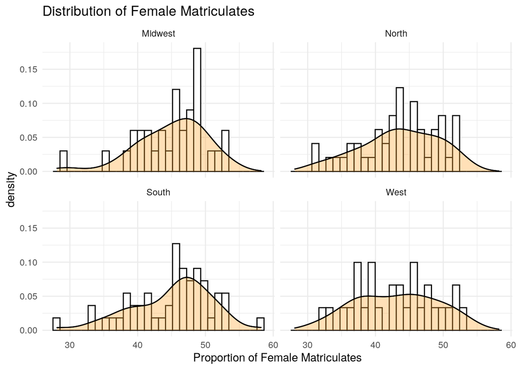

```r
joined_data %>% filter(!is.na(Region)) %>% ggplot(aes(femalematriculants)) +
    geom_histogram(aes(y = ..density..), colour = "black", fill = "white") +
    geom_density(alpha = 0.2, fill = "yellow") + facet_wrap(~Region) +
    geom_density(alpha = 0.2, fill = "#FF6666") + theme_minimal() +
    ggtitle("Distribution of Female Matriculates") + scale_x_continuous(breaks = seq(from = 30,
    to = 60, by = 10), name = "Proportion of Female Matriculates")
```

There appears to be the highest frequency of female matriculates to medical schools in the South and Midwest regions, whereas the West region contains the lowest frequency of female matriculates. This may be attributed to the lower annual average applications that the West receives, as well as its overall lack of medical schools.

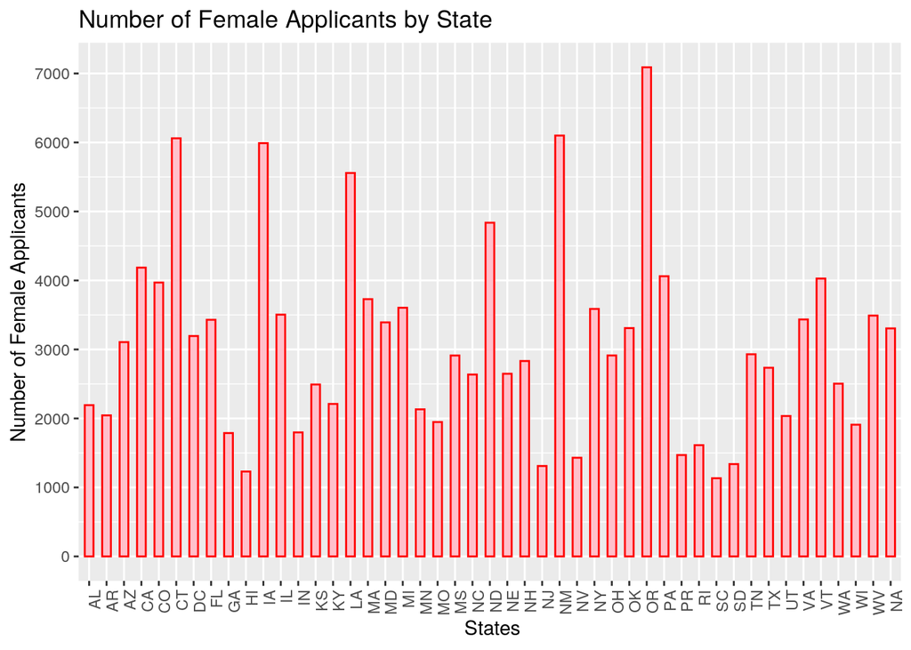

```r
joined_data %>% ggplot(aes(x = State)) + geom_bar(aes(y = femaleapplicants),
    stat = "summary", width = 0.5, position = position_dodge(0.8),
    fill = "pink", color = "red") + ggtitle("Number of Female Applicants by State") +
    theme(axis.text.x = element_text(angle = 90, hjust = 1)) +
    scale_x_discrete(name = " States") + scale_y_continuous(breaks = seq(from = 0,
    to = 7000, by = 1000), name = "Number of Female Applicants")
```

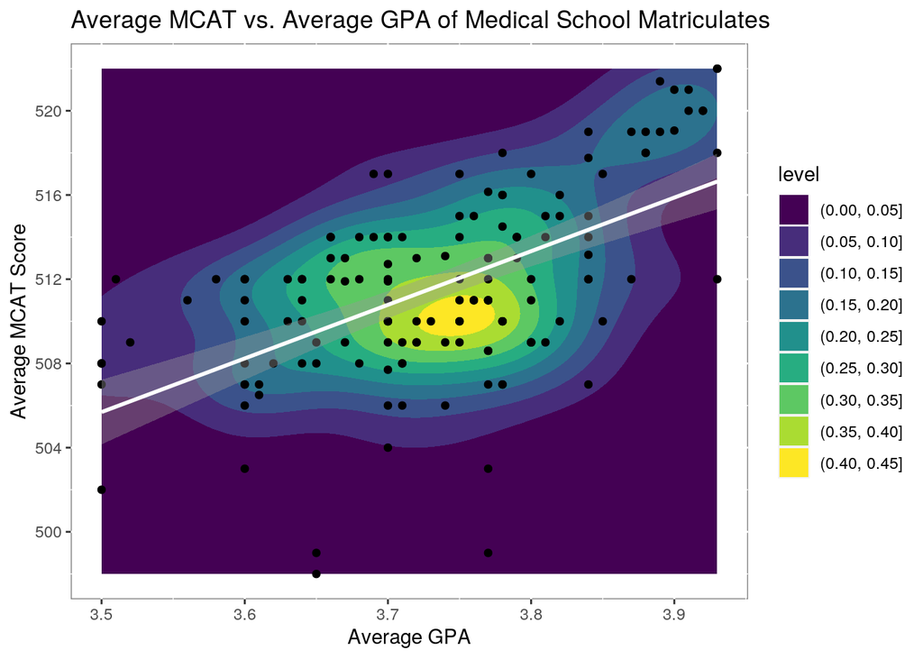

```r
joined_data %>% ggplot(aes(x = `Average GPA`, y = `Average MCAT`)) +
    geom_density2d_filled() + geom_point() + scale_y_continuous(breaks = seq(from = 500,
    to = 528, by = 4), name = "Average MCAT Score") + theme(panel.background = element_rect(fill = "white",
    colour = "grey50")) + ggtitle("Average MCAT vs. Average GPA of Medical School Matriculates") +
    geom_smooth(method = "lm", colour = "white")
```

The areas of the plot with the greatest “density” of GPA and MCAT scores is depicted by the yellow region; the purple area shows the least “density” of GPA and MCAT scores. In other words, most matriculates have an average GPA around 3.75, and an average MCAT score around 510. As depicted by the white trend line, there is a positive correlation between a matriculates average GPA and MCAT score.